# Breaking Predict with lm()

Robert W. Walker

11/11/2019

## lm() Syntax is Important

I will refer to an example from a recent homework on regression. The data cover total costs per period and `Fertilizer` [sugar and wheat] production in a factory in Tennessee. I will embed the data in the first code chunk.

```r
Fertilizer <- structure(list(TotalCost = c(656173, 619058, 668676, 622302,
632286, 672717, 602916, 643074, 552836, 613314, 700822, 552576,
579878, 668761, 735812, 665795, 670082, 550066, 593947, 613121,
609388, 735423, 536458, 638920, 755232, 613023, 543013, 620659,
538868, 588713, 601981, 558313, 640537, 637230, 567228, 532145,
672828, 649695, 663317, 586153, 611113, 612919, 654498, 651475,
507135, 625520, 617906, 573349, 657173, 629154), Wheat = c(6061,
3478, 6192, 7245, 4641, 7469, 5778, 6282, 1833, 1200, 7863, 1764,
1200, 6132, 9107, 7281, 4616, 1330, 5262, 3506, 6064, 8893, 2542,
5212, 9081, 6062, 1633, 5222, 1200, 2495, 1431, 1200, 6272, 5729,
1406, 2122, 6344, 7511, 6459, 1563, 4418, 1200, 4351, 6388, 1721,
6339, 1200, 1520, 6625, 5042), Sugar = c(2875, 5636, 3535, 1817,
4820, 1400, 2397, 2806, 6791, 8854, 1747, 6686, 8393, 3183, 1400,
1746, 5393, 7396, 3402, 6023, 2446, 1400, 5877, 4790, 1400, 2654,
7619, 3967, 7762, 6592, 8217, 7783, 2534, 3250, 7433, 5828, 3124,
1400, 2478, 8046, 4056, 8648, 5191, 2818, 6292, 2169, 8473, 7378,
2472, 4344), Total.Production = c(8936, 9114, 9727, 9062, 9461,
8869, 8175, 9088, 8624, 10054, 9610, 8450, 9593, 9315, 10507,
9027, 10009, 8726, 8664, 9529, 8510, 10293, 8419, 10002, 10481,
8716, 9252, 9189, 8962, 9087, 9648, 8983, 8806, 8979, 8839, 7950,
9468, 8911, 8937, 9609, 8474, 9848, 9542, 9206, 8013, 8508, 9673,
8898, 9097, 9386)), row.names = c(NA, 50L), class = "data.frame")
summary(Fertilizer)
```

```
##    TotalCost          Wheat          Sugar      Total.Production
##  Min.   :507135   Min.   :1200   Min.   :1400   Min.   : 7950
##  1st Qu.:586793   1st Qu.:1732   1st Qu.:2492   1st Qu.: 8814
##  Median :619858   Median :5127   Median :4200   Median : 9088
##  Mean   :620872   Mean   :4510   Mean   :4655   Mean   : 9165
##  3rd Qu.:655754   3rd Qu.:6325   3rd Qu.:6765   3rd Qu.: 9580
##  Max.   :755232   Max.   :9107   Max.   :8854   Max.   :10507
```

## A Linear Regression: lm()

There are a few ways to deploy lm to estimate linear models. We will require the formula syntax to make full use of R’s capabilities. I will work with the threeT ways that deploy `$` syntax, the formula syntax, and new variables. In all three cases, I want TotalCost as a function of Total.Production.

```r
Model.Form <- lm(TotalCost~Total.Production, data=Fertilizer)
```

First, the above `formula` syntax is really the only correct way to do it to assure full functionality to R’s lm(). We could also refer to each variable in their location$name form as I do next.

```r
Dollar.Form <- lm(Fertilizer$TotalCost~Fertilizer$Total.Production)
```

Finally, I could create new variables and put them together in a regression.

```r
Costs <- Fertilizer$TotalCost
Total.Production <- Fertilizer$Total.Production
Nothing.Form <- lm(Costs~Total.Production)
```

Now the model summaries, they are identical.

```r
summary(Model.Form)
```

```
##
## Call:
## lm(formula = TotalCost ~ Total.Production, data = Fertilizer)
##
## Residuals:
##    Min     1Q Median     3Q    Max
## -83035 -34050   1934  38114  69332
##
## Coefficients:
##                  Estimate Std. Error t value Pr(>|t|)
## (Intercept)      78579.72   92318.38   0.851    0.399
## Total.Production    59.17      10.05   5.886 3.74e-07 ***
## ---
## Signif. codes:  0 '***' 0.001 '**' 0.01 '*' 0.05 '.' 0.1 ' ' 1
##
## Residual standard error: 41750 on 48 degrees of freedom
## Multiple R-squared:  0.4192, Adjusted R-squared:  0.4071
## F-statistic: 34.65 on 1 and 48 DF,  p-value: 3.74e-07
```

```r
summary(Dollar.Form)
```

```
##
## Call:
## lm(formula = Fertilizer$TotalCost ~ Fertilizer$Total.Production)
##
## Residuals:
##    Min     1Q Median     3Q    Max
## -83035 -34050   1934  38114  69332
##
## Coefficients:
##                             Estimate Std. Error t value Pr(>|t|)
## (Intercept)                 78579.72   92318.38   0.851    0.399
## Fertilizer$Total.Production    59.17      10.05   5.886 3.74e-07 ***
## ---
## Signif. codes:  0 '***' 0.001 '**' 0.01 '*' 0.05 '.' 0.1 ' ' 1
##
## Residual standard error: 41750 on 48 degrees of freedom
## Multiple R-squared:  0.4192, Adjusted R-squared:  0.4071
## F-statistic: 34.65 on 1 and 48 DF,  p-value: 3.74e-07
```

```r
summary(Nothing.Form)
```

```
##
## Call:
## lm(formula = Costs ~ Total.Production)
##
## Residuals:
##    Min     1Q Median     3Q    Max
## -83035 -34050   1934  38114  69332
##
## Coefficients:
##                  Estimate Std. Error t value Pr(>|t|)
## (Intercept)      78579.72   92318.38   0.851    0.399
## Total.Production    59.17      10.05   5.886 3.74e-07 ***
## ---
## Signif. codes:  0 '***' 0.001 '**' 0.01 '*' 0.05 '.' 0.1 ' ' 1
##
## Residual standard error: 41750 on 48 degrees of freedom
## Multiple R-squared:  0.4192, Adjusted R-squared:  0.4071
## F-statistic: 34.65 on 1 and 48 DF,  p-value: 3.74e-07
```

So are the confidence intervals for the slope(s) and intercept and anova will generally work as expected.

```r
confint(Model.Form)
```

```
##                          2.5 %       97.5 %
## (Intercept)      -107038.80975 264198.25859
## Total.Production      38.96039     79.38555
```

```r
confint(Dollar.Form)
```

```
##                                     2.5 %       97.5 %
## (Intercept)                 -107038.80975 264198.25859
## Fertilizer$Total.Production      38.96039     79.38555
```

```r
confint(Nothing.Form)
```

```
##                          2.5 %       97.5 %
## (Intercept)      -107038.80975 264198.25859
## Total.Production      38.96039     79.38555
```

All three behave exactly as desired.

## Predicting require Formulae

Using `formula` everything behaves as expected. Let me predict the confidence interval of average total costs. I do this in two steps. First, I create a new data.frame that contains only one variable: Total.Production. It only takes the value of 9000. That is the average costs given units produced that I wish to predict.

```r
Hypothetical.Data <- data.frame(Total.Production=9000)
predict(Model.Form, newdata = Hypothetical.Data, interval="confidence")
```

```
##        fit      lwr      upr
## 1 611136.4 598809.3 623463.5
```

```r
predict(Dollar.Form, newdata = Hypothetical.Data, interval="confidence")
```

```
##         fit      lwr      upr
## 1  607349.4 594612.3 620086.5
## 2  617882.1 605968.2 629796.1
## 3  654155.2 637718.7 670591.6
## 4  614805.1 602755.6 626854.7
## 5  638415.2 625118.2 651712.2
## 6  603384.8 590096.5 616673.0
## 7  562318.7 539060.8 585576.6
## 8  616343.6 604373.2 628314.1
## 9  588887.4 572754.8 605020.0
## 10 673504.7 651961.0 695048.5
## 11 647231.9 632333.1 662130.8
## 12 578591.3 559896.9 597285.6
## 13 646226.0 631532.2 660919.7
## 14 629775.9 617522.3 642029.5
```

[output cut: 36 more lines]

That gives me back the confidence interval of the average total costs for each actual value of production in the data [those are stored in the lm() object as `fitted.values` – the points on the line/plane. That is an effect of the syntax; the `newdata` bit cannot really replace `Fertilizer$Total.Production` with the single value 9000 without rewriting the data itself. Nor is there a variable called `Fertilizer$Total.Production` inside `Hypothetical.Data`; there cannot be because that violates the conventions of naming and the syntactical use of `$`.

What about my other strategy? Peel off production and costs and then use `lm()`.

## New variables?

```r
predict(Nothing.Form, newdata = Hypothetical.Data, interval="confidence")
```

```
##        fit      lwr      upr
## 1 611136.4 598809.3 623463.5
```

## Effects Plots

Last time, we looked at some basic regression plots. In this case,

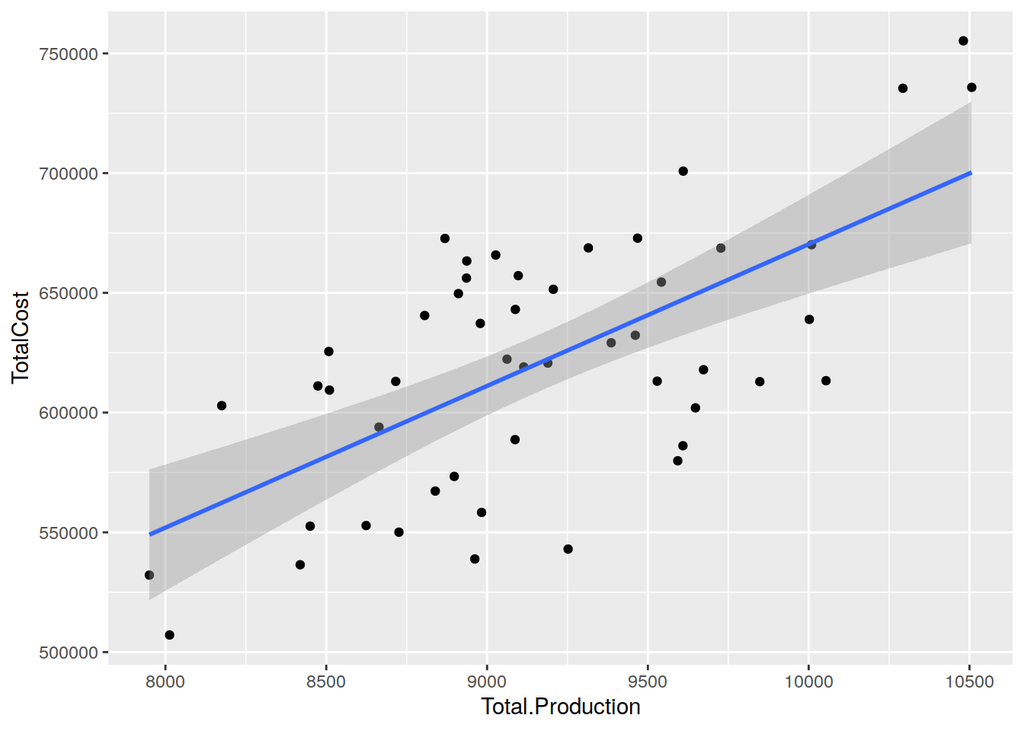

```r
ggplot(Fertilizer, aes(x=Total.Production, y=TotalCost)) + geom_point() + geom_smooth(method="lm")
```

It is important to note that this is an x-y scatterplot. What happens if we try that for the two input example? First, let me show a simple plot that should capture what is going on.

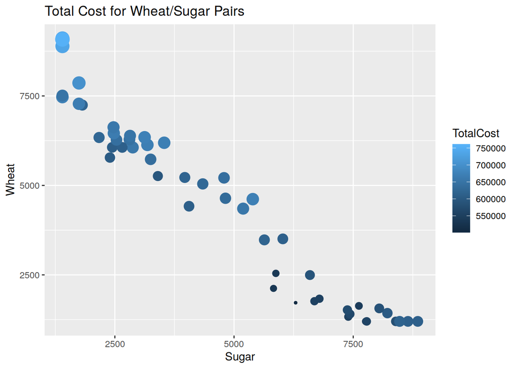

```r
ggplot2::ggplot(Fertilizer, aes(x=Sugar, y=Wheat, color=TotalCost, size=TotalCost)) + geom_point() + scale_size_continuous(guide=FALSE) + labs(title="Total Cost for Wheat/Sugar Pairs")
```

Now, estimate the regression.

```r
Mod.SW <- lm(TotalCost ~ Sugar+Wheat, data=Fertilizer)
```

### The plots?

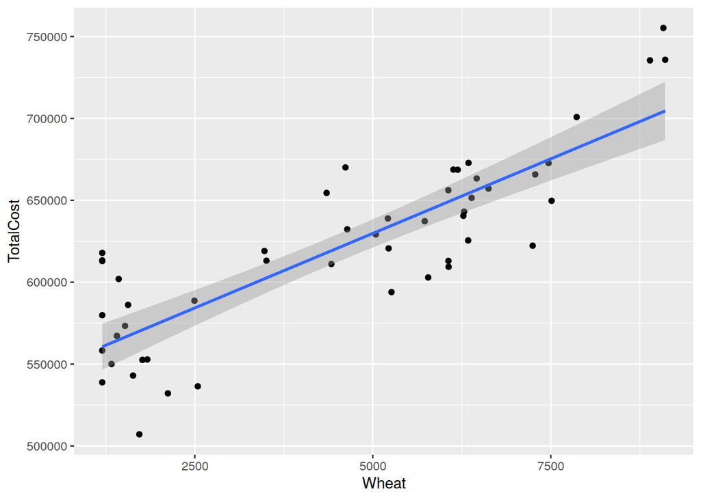

```r
ggplot2::ggplot(Fertilizer, aes(x=Wheat, y=TotalCost)) + geom_point() + geom_smooth(method="lm")
```

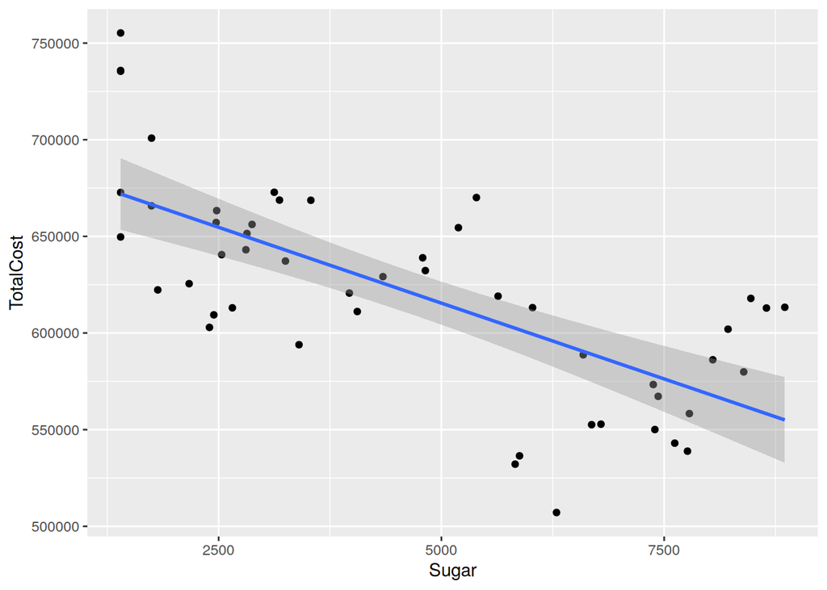

```r
ggplot2::ggplot(Fertilizer, aes(x=Sugar, y=TotalCost)) + geom_point() + geom_smooth(method="lm")
```

Uh oh. How to fix that? We need to show it holding wheat units constant. That’s a partial plot, or in R an `effects` plot.

```r
library(effects)
```

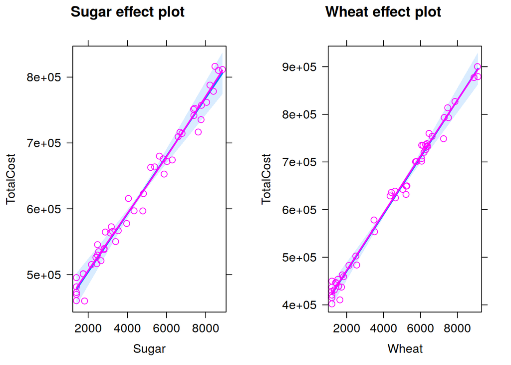

```r
plot(allEffects(Mod.SW, partial.residuals=TRUE))
```

Notice the difference in the y-axes, it obscures the relevant difference in the slopes. Fix the limits across plots?

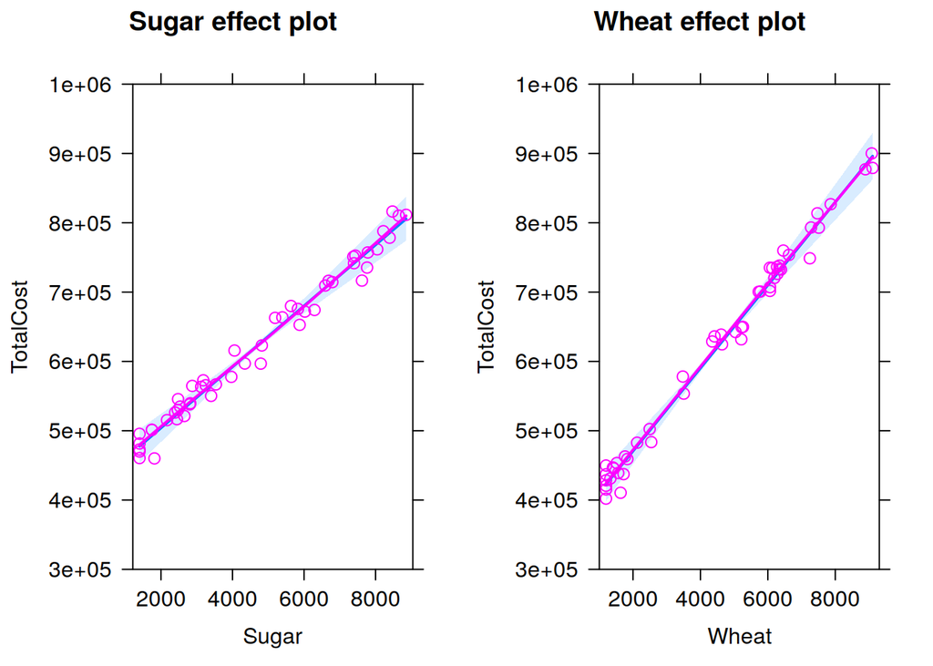

```r
library(effects)
plot(allEffects(Mod.SW, partial.residuals=TRUE), ylim=c(300000,1000000))
```

## Other Plots

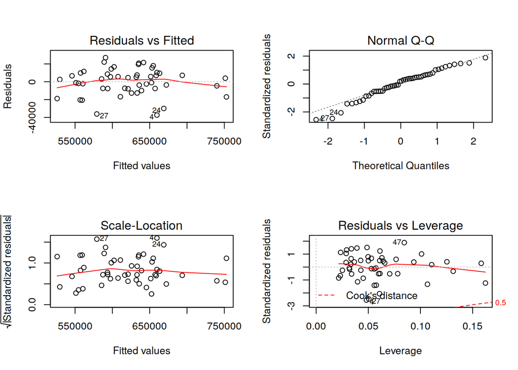

```r
par(mfrow=c(2,2))
plot(Mod.SW)
```